# `phyr`: An R package for phylogenetic species-distribution modelling in ecological communities

Daijiang Li<sup>1</sup>, Russell Dinnage<sup>2,3</sup>, Lucas Nell<sup>4</sup>, Matthew R. Helmus<sup>5</sup>, Anthony R. Ives<sup>4†</sup>

20 July, 2020

Running Title: Model-based phylogenetic analyses

<sup>1</sup> Department of Wildlife Ecology & Conservation, University of Florida, Gainesville, FL 32611  
<sup>2</sup> Research School of Biology, Australian National University, Acton ACT 2601, Australia  
<sup>3</sup> Institute for Applied Ecology, University of Canberra, Bruce ACT 2617, Australia  
<sup>4</sup> Department of Integrative Biology, University of Wisconsin-Madison, Madison, WI 53706  
<sup>5</sup> Integrative Ecology Lab, Center for Biodiversity, Department of Biology, Temple University, Philadelphia, PA 19122

Emails: daijianglee@gmail.com; r.dinnage@gmail.com; lucas@lucasnell.com; mrhelmus@temple.edu; arives@wisc.edu  
† Corresponding author

*Summary*

1. Model-based approaches are increasingly popular in ecological studies. A good example of this trend is the use of joint species distribution models to ask questions about ecological communities. However, most current applications of model-based methods do not include phylogenies despite the well-known importance of phylogenetic relationships in shaping species distributions and community composition. In part, this is due to a lack of accessible tools allowing ecologists to fit phylogenetic species distribution models easily.
2. To fill this gap, the R package `phyr` (pronounced fire) implements a suite of metrics, comparative methods and mixed models that use phylogenies to understand and predict community composition and other ecological and evolutionary phenomena. The `phyr` workhorse functions are implemented in C++ making all calculations and model estimations fast.
3. `phyr` can fit a variety of models such as phylogenetic joint-species distribution models, spatiotemporal-phylogenetic autocorrelation models, and phylogenetic trait‐based bipartite network models. `phyr` also estimates phylogenetically independent trait correlations with measurement error to test for adaptive syndromes and performs fast calculations of common alpha and beta phylogenetic diversity metrics. All `phyr` methods are united under Brownian motion or Ornstein-Uhlenbeck models of evolution and phylogenetic terms are modelled as phylogenetic covariance matrices.
4. The functions and model formula syntax we propose in `phyr` provide an easy-to-use collection of tools that we hope will ignite the use of phylogenies to address a variety of ecological questions.

*Keywords*: phylogenetic diversity, phylogenetic generalized linear mixed models, functional trait, trait correlation, model-based methods, Joint Species Distribution Model

# Introduction

Ecological communities are collections of species that occur within the same geographical area. Which species occur within communities depends on the dispersal ability of species to enter the community, the environmental conditions that they find there, and the interactions that they have with other species in the community. For example, the larvae of an aquatic insect species might only occur in a particular lake if its adult stage has long-distance flight capabilities, if it can tolerate the low pH of the lake, and if it can avoid the predators that are common. These three processes – dispersal, environmental tolerance, and species interactions – depend on the traits that species possess and hence reflect evolutionary history and biogeographic processes (Warren, Cardillo, Rosauer, & Bolnick, 2014; Gerhold, Carlucci, Procheş, & Prinzing, 2018). Differences in community composition among locations depends on the variation in abiotic and biotic characteristics of the locations (Whittaker, 1956). Continuing with our example of aquatic insects, an insect species might occur in two nearby lakes because they both have low pH, or because they have the same predator community. Nearby lakes might also have the same insect species if the adult insects readily disperse between lakes. Thus, understanding the composition of a community, and the variation in composition among communities, requires understanding both species traits and environmental variables that together govern what species can occur where, and whether they can get there.

The importance of species traits, environmental characteristics, and geographical location for community composition imply that statistical analyses of community composition should be capable of incorporating all of these types of factors. For any statistical analysis, a model specifies variables that might explain the presence or abundance of species (predictor or independent variables) and the statistical structure of the unexplained variation. Even though species traits may ultimately dictate whether a species can occur in a specific community, it is unlikely that all relevant traits are known and measured for every species. Consequently, the effects of these traits will be treated as “unexplained variance” in the model. Nonetheless, because phylogenetically related species often have similar trait values, the unexplained variance will likely have phylogenetic signal (Felsenstein, 1985; Freckleton, Harvey, & Pagel, 2002; Blomberg, Garland Jr, & Ives, 2003). Therefore, statistical models of community composition should account for phylogenies (Losos, 1996; Webb, 2000; Webb, Ackerly, McPeek, & Donoghue, 2002; Cavender-Bares, Ackerly, Baum, & Bazzaz, 2004; Helmus, Savage, Diebel, Maxted, & Ives, 2007; Frishkoff, Valpine, & M’Gonigle, 2017; Li et al., 2017). Similarly, environmental factors differing among locations that are unknown or unmeasured might nonetheless be more similar among locations that are close to each other. This will generate spatial autocorrelation in the unexplained variance among communities (Cressie, 1991; Ives & Zhu, 2006). Spatial autocorrelation can also be generated by the dispersal of individuals among nearby communities (Moran, 1953; Royama, 2012). Thus, the analysis of community composition requires statistical models that can explicitly include species traits and environmental factors, and also include them implicitly in the form of phylogenetic relationships among species and geographical distances among locations in the unexplained variance terms of the model.

Statistical models for phylogenetic community composition provide flexible tools for exploring the many possible factors underlying the distribution of species and the composition of communities (Ives & Helmus, 2011; Ovaskainen & Soininen, 2011; Warton et al., 2015). The models can describe complex relationships in the data, such as how phylogenetically related species might respond similarly to the same environmental gradient, or how phylogenetically related species might exclude each other from the same communities. They also give a firm statistical basis to test these patterns, the ability to simulate data sets from the fitted model, and the ability to predict the composition of unsurveyed communities.

Analyzing the composition of communities in a phylogenetic context may generate additional statistical questions about the evolutionary processes that have generated the distribution of values of traits among species. For example, two insect species that occur in the same lake might share both long-range flight abilities and tolerance to low pH. Is the positive correlation between these two traits caused by correlated selective forces? A challenge to answering this type of question is that phylogenetic correlations between trait values might reflect species phylogenetic relatedness rather than shared selection: two species might have both long-range flight abilities and tolerance to low pH only because they are phylogenetically closely related. To distinguish between these two explanations – convergence of suites of traits due to shared selective forces versus similarity due to phylogenetic relatedness – it is necessary to account for phylogenies when performing correlation analyses between traits that could explain similarities in the distributions of species.

The R package `phyr` is designed to allow users to easily develop a rich collection of models for the analyses of ecological communities that include phylogenetic correlations among species and/or spatial correlation among locations. Below, we first give a brief overview of the structure and syntax of two key functions `pglmm()` and `cor_phylo()`. `pglmm()` allows the formulation of a diverse set of phylogenetic generalized linear models (PGLMM) that can be used not only to analyze phylogenetic community composition but also comparative models for Gaussian and non-Gaussian data. `cor_phylo()` computes the Pearson correlations among species traits while simultaneously estimating the strength of phylogenetic signal within each trait. We then compare `pglmm()` and `cor_phylo()` to methods and programs that are currently available. Finally, we apply `pglmm()` and `cor_phylo()` to simulated data to illustrate their implementation and output.

# Overview of `phyr`

`Phyr` contains three groups of functions (Table 1): phylogenetic generalized linear mixed models (`pglmm()`), phylogenetic comparative methods (`cor_phylo()` and `pglmm_compare()`), and community phylogenetic diversity metrics (e.g., `psv()`, `pse()`). The workhorse functions of all groups are written in C++ to increase computational speed. Here, we will focus on the first two groups of functions (especially `pglmm()` and `cor_phylo()`), because they are more complicated and less readily available to practitioners than community phylogenetic diversity metrics.

Table 1: List of main functions in the `phyr` package.

| Group | Main Functions | Brief Description |
| --- | --- | --- |
| Mixed Models | pglmm() | Phylogenetic Generalised Linear Mixed Model for ecological community data (e.g., species composition across sites; bipartite interactions) |
| Comparative Methods | cor_phylo() | Correlations among multiple traits with phylogenetic signal |
|  | pglmm_compare() | pglmm() tailored for comparative data in which species (tips of a phylogeny) only occur once |
| Metrics | psv(); pse(); psr(); psc(); psd() | Phylogenetic alpha diversity of communities |
|  | pcd() | Pairwise phylogenetic beta diversity of communities |
|  | vcv2() | Convert a phylogeny to a covariance matrix, a faster version of ape::vcv() |

## *`pglmm()`*

Function `pglmm()` constructs and fits generalized linear mixed models that incorporate covariance matrices containing the phylogenetic relationships among species. The syntax for `pglmm()` resembles that used in the R package `lme4` (Bates, Mächler, Bolker, & Walker, 2015), and indeed `pglmm()` will fit most of the models that can be fit with `lmer()` and `glmer()`. `pglmm()` goes beyond `lmer()`and `glmer()` by allowing the specification of covariance matrices, which could be phylogenetic covariance matrices or any other covariance matrices that the user defines (e.g., spatial or temporal autocorrelation matrix). `pglmm()` can also fit models with “nested” covariance structures (e.g., a species phylogenetic covariance matrix nested within a site covariance matrix). `pglmm()` can operate in both frequentist mode, with the distribution of species among communities being Gaussian, binary, binomial or Poisson, and Bayesian mode with the addition of zero-inflated binomial and Poisson distributions. Finally, it is our hope that the formula syntax of `pglmm()` can be used to fit similar models with other programs such as Stan (e.g. via R package `brms` Bürkner, 2018).

A general example of the syntax for `pglmm()` is

```r
pglmm(
  Y ~ trait * env +
    (1 | sp__) +
    (1 | site__) +
    (trait | site) +
    (env | sp__) +
    (1 | sp__@site),
  data = data,
  cov_ranef = list(sp = phy.sp, site = V.space),
  family = 'binomial',
  bayes = FALSE,
  REML = TRUE
)
```

Here, Y is a binary (Bernoulli) dependent variable which takes values of either 0 or 1. The specification `family = 'binomial'` allows binary data and also binomial data for which Y is a matrix containing columns for successes and failures. The independent variables `trait` and `env` take on different values for each species and site, respectively. Sites (`site`) and species (`sp`) are treated as random effects: `(1|site)` implies that a value from a Gaussian random variable is picked for each site, thereby representing unmeasured differences among sites. For the case of species, the double underscore in `(1|sp__)` implies that, in addition to a random effect for species, there is a second random effect which contains the phylogenetic relationships among species (or some other correlation structure specified by the user). The phylogenetic random effect assumes that values for each species are picked from a multivariate Gaussian distribution with phylogenetic covariance matrix $\Sigma$. A covariance matrix $\Sigma$ is specified by `cov_ranef = list(sp = phy.sp, site = V.space)`. The covariance matrix `phy.sp` associated with species can be a `phylo` object from the R package `ape` (Paradis & Schliep, 2018). To construct $\Sigma$ from a ‘phylo’ object, `pglmm()` assumes that the residual variation associated with species follows a Brownian motion model of evolution, so that the covariance between species is proportional to their shared evolutionary history (e.g., shared branch length on a phylogeny). It is also possible to specify an explicit covariance matrix, such as `site = V.space`, where `V.space` is a covariance matrix created from the distance between sites. For example, if we assume that spatial correlations follow a Gaussian function, then the correlation in residuals from sites *i* and *j* located a distance $d_{ij}$ from each other is $\exp(-(d_{ij}/r)^2)$, where *r* is the “range” giving how quickly spatial correlation decreases with distance (Besag & Moran, 1975).

The syntax `(1|sp__)` or `(1|site__)` generates two random effects, one without and one with phylogenetic or spatial covariances; in contrast, `(1|sp)` would generate only a single random effect that is independent among species. `pglmm()` forces in a term for `(1|sp)` whenever `(1|sp__)` is specified, because otherwise any difference among species would be captured by the diagonal elements in $\Sigma$ even in the absence of covariances among phylogenetically related species which are specified by the off-diagonal elements of $\Sigma$. Therefore, if `(1|sp)` were not included, this could lead to the identification of phylogenetic signal in the abundances of species even in its absence from a community. To account for differences among sites in how they select for species with different traits, `(trait|site)` allows the slope of Y against `trait` to be a Gaussian random variable. Similarly, to account for the differences among species for how they respond to `env`, `(env|sp__)` allows the relationship of Y against `env` to be given by two slopes, the first slope that is picked from a Gaussian random variable in which species are independent and the second slope that is picked from a multivariate Gaussian with covariance matrix $\Sigma$. Finally, `(1|sp__@site)` generates a nested term: within a site, the residual variation in Y shows phylogenetic relatedness, with phylogenetically related species more likely to occur in the same site. Note that `(1|sp__)` differs from `(1|sp__@site)` because `(1|sp__)` generates differences in the mean value of Y for species across all sites, whereas `(1|sp__@site)` is local to sites, giving the covariances among species only within sites. This nested term can be used to test for community clustering or overdispersion (Webb et al., 2002; Ives & Helmus, 2011). Other forms of a nested term are available in `pglmm()`, which can be used to study more complicated questions such as bipartite networks.

With `bayes = FALSE`, `pglmm()` is fitted using a frequentist approach. ML or REML is used for fitting, with `REML = TRUE` as the default. For a non-Gaussian model (e.g., `family = 'binomial'`), an iterated quasi-likelihood method is used for model fitting which gives the approximate likelihood; p-values for the fixed effects are given by a Wald test and for the random effects by profile likelihood, although we recommend bootstrap-based tests when computationally feasible. Note that `REML = TRUE` is an option for non-Gaussian models (in contrast to `glmer()`) due to the algorithm used. With `bayes = TRUE`, a Bayesian approach is implemented using INLA (Rue, Martino, & Chopin, 2009), which gives parameter estimates and credible intervals. For large problems with the number of species-site combinations exceeding 2000, the Bayesian computations are considerably faster than the frequentist computations. Finally, a key to interpreting the results from a model is understanding the structure of the covariance matrices associated with the random effects. Therefore, `pglmm()` has associated plotting functions `pglmm_plot_ranef()` that present the design matrices for the random effects (Fig. 1).

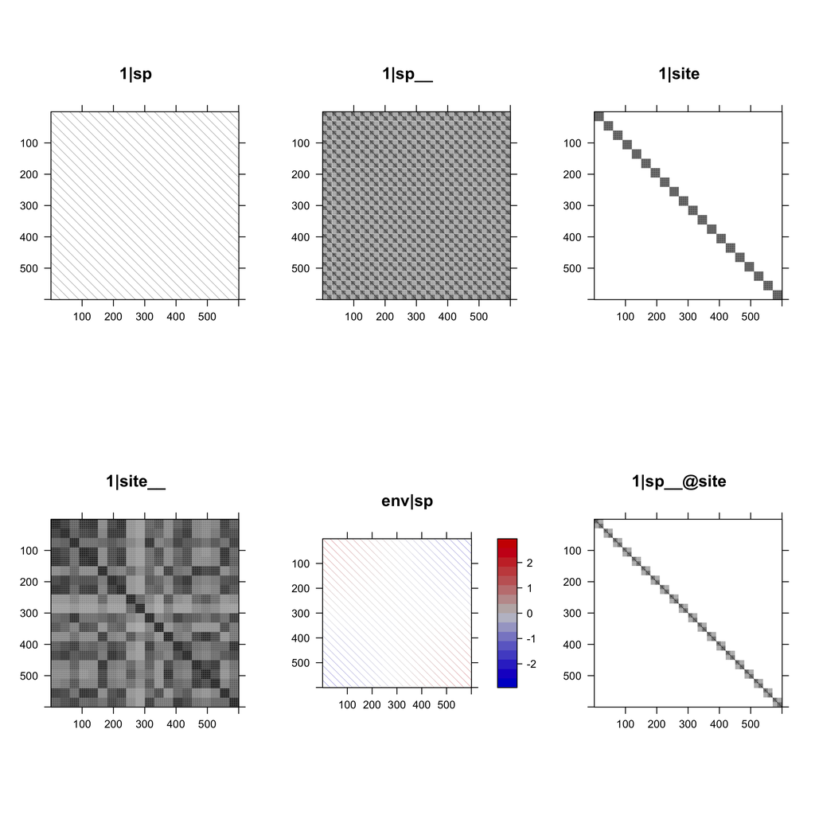

Whereas `pglmm()` is designed to accept community composition data, in which the same species can occur in multiple sites, the algorithm used by `pglmm()` can equally be used for comparative data in which each species is represented by only a single data point. `pglmm_compare()` is a wrapper for `pglmm()` that is tailored for comparative data and thus provides an easy-to-use function for analyzing non-Gaussian phylogenetic data.

## *`cor_phylo()`*

`cor_phylo()` makes it possible to compare suites of traits among species, accounting for their phylogenetic relatedness (Zheng et al., 2009; Johnson, Ives, Ahern, & Salminen, 2014). To identify suites of traits under joint selection, such as traits that together make up adaptive syndromes, it is necessary to perform a correlation analysis in which phylogenetic relatedness is factored out. `cor_phylo()` does this. It can also include within-species variation (e.g., measurement error) which should better-expose the underlying correlations in traits among species. Whereas `pglmm()` can be used to identify the composition of communities within a region, `cor_phylo()` can be used to assess patterns of traits among species that make up the regional species pool.

The syntax for `cor_phylo()` is

```r
cor_phylo(
  variates = ~ trait1 + trait2,
  species = ~ sp,
  phy = phy.sp,
  covariates = list(trait1 ~ env),
  meas_errors = list(trait1 ~ me1, trait2 ~ me2),
  data = data,
  boot = 2000
)
```

In this example, the correlation between `trait1` and `trait2` is computed, and the column named `sp` in `data` identifies the species. The object `phy.sp` specifies the phylogenetic covariance matrix as a ‘phylo’ object from the `ape` package. `cor_phylo()` estimates the phylogenetic signal for each trait by assuming that trait evolution is given by a Ornstein-Uhlenbeck process. The term `covariates = list(trait1 ~ env)` includes the independent variable `env` for `trait1`, to remove possible confounding effects; only an intercept is estimated if no covariate is provided for a trait. Covariates are linear terms fit using the generalized least squares estimation equation (Martins & Hansen, 1997). Within-species variation is specified by `meas_errors = list(trait1 ~ me1, trait2 ~ me2)`, where `me1` and `me2` are the standard errors for `trait1` and `trait2`, respectively, of values at the tips of the phylogenetic tree. If within-species standard errors are not provided for a given trait, the trait values are assumed to be known without error. Finally, `cor_phylo()` can perform parametric bootstrapping to give confidence intervals for all parameter estimates: correlations, phylogenetic signals, covariate coefficients, and coefficient covariances.

# Relationships to other methods and software

Earlier versions of `pglmm()` and `cor_phylo()` both appear in existing R packages (`pez` (Pearse et al., 2015) and `ape` (Paradis & Schliep, 2018), respectively), although the versions in `phyr` represent considerable improvements in ease-of-use, computational speed, and flexibility. Both have new syntax that makes them more intuitive to use. `pglmm()` also has new associated functions that plot the design of the covariance matrices (Fig. 1), making model interpretation easier. Both are now coded in C++ (for key functions), which speeds computation time by 5-10X. `pglmm()` now supports several non-Gaussian distributions and allows Bayesian analyses using INLA (Rue et al., 2009) that is particularly useful for large datasets. Finally, both include more output; for example, both now report the log-likelihood and related measures AIC and BIC. The log-likelihood makes it possible to compare full models to reduced models with some parameters removed, using likelihood ratio test (e.g., Neter, Wasserman, & Kutner, 1989) to give the significance of a collection of parameters. AIC and BIC can be used for model selection (Burnham & Anderson, 2002).

## *`pglmm()`*

`pglmm()` is syntactically modeled after `lmer()` and `glmer()` in `lme4` (Bates et al., 2015), although it allows the specification of phylogenetic covariance matrices. `pglmm()` also allows “nested” models (with block-diagonal covariance matrices) which arise when phylogenetic covariances only act within single communities, rather than among communities; an example is illustrated by the `(1|sp__@site)` term in Fig. 1. Such nested models make it possible to assess whether phylogenetic relatedness affects the abundance of species within the same communities, such as whether competition between closely related species excludes one of the competitors from communities where the other is present. This is the case in the distribution of fish among lakes: after accounting for the effect of pH excluding some species from some lakes, a pattern of exclusion occurs in which phylogenetically related species are less likely to occur in the same lakes (Helmus et al., 2010). Nested models are structurally incompatible with the architecture of `lme4`.

There are alternative programs to `pglmm()`, although they have limitations that `pglmm()` overcomes. Hadfield, Krasnov, Poulin, & Nakagawa (2013) use the R package `MCMCglmm` (Hadfield, 2010) to perform phylogenetic community analyses, although they also use ASReml because its penalized quasi-likelihood (PQL) approach is computationally much faster. Hierarchical Modelling of Species Communities (HMSC-R) (Tikhonov et al., 2019) performs community analyses using Bayesian MCMC approaches, although it does not include nested terms. It is also possible to code specific phylogenetic community models using flexible Bayesian platforms such as WinBugs, Stan, and JAGS, although this will involve considerable programming and expertise.

### PGLMM as a Joint Species Distribution Model (JSDM)

Joint Species Distribution Models (JSDMs) are models where the response variable is distribution (abundances or occurrences) of multiple species across sites or samples, where all species are modeled jointly, usually by allowing non-zero covariance between either species-level errors, species-level coefficients in the model, or both (Warton et al., 2015). `pglmm()` in `phyr` is a joint species distribution model where the (residual) dependencies among species are modeled in a way that incorporates phylogenetic relatedness. JSDMs, and Species Distribution Models (SDM) in general, have typically been focused on producing accurate predictions of how species are distributed, usually in a geographic context. However, they can also be used for making inferences about the biology of species, such as which environmental factors are important in explaining the distribution of a species or set of species, and whether traits or evolutionary history can help explain these distributions. It is this kind of inference that is the focus of the JSDM implemented in `pglmm()`. There is often a trade-off between improving predictions and making solid inferences, because increasing the complexity or flexibility of a model can improve its predictive power, but this same complexity makes it more difficult to understand what biology is being represented by the model outputs. By incorporating phylogenetic information, `pglmm()` has two uses. First, by identifying correlations that might be expected among species due to phylogeny, `pglmm()` gives better statistical properties for tests of factors underlying community composition. For example, Li & Ives (2017) show that failure to account for phylogenetic correlations can inflate type I errors in tests for associating environmental variables and traits that underlie community composition. Second, `pglmm()` allows explicit focus on the importance of evolutionary history in structuring species assemblages, since phylogenetic covariances are explicitly estimated. This is in contrast to many other JSDMs (e.g. those in described in Wilkinson, Golding, Guillera-Arroita, Tingley, & McCarthy, 2019), which attempt to estimate all pairwise species covariances without accounting for phylogeny.

Of course, the goals of solid inference and prediction are not mutually exclusive. Good prediction requires avoiding overfitting, which can be facilitated by reducing the number of parameters in the model. In some systems, it may be possible to make better predictions using a simple phylogenetic model if phylogeny is a strong predictor of species covariance, or if many species are poorly sampled and thus estimating covariances between them individually results in higher prediction variance. Using phylogeny can help closely related species share statistical strength through phylogenetic partial pooling. Ultimately, it can be powerful to use the same kind of statistical framework to do both predictive and inferential work in ecology, because it allows ecologists to smoothly move between these two goals and more easily and quickly draw mutual insights between them.

## *`cor_phylo()`*

The R package `mvMORPH` (Clavel, Escarguel, & Merceron, 2015) can fit a broad range of models, of which `cor_phylo()` can be formulated as a special case. While `cor_phylo()` does not have the flexibility of `mvMORPH`, it is correspondingly simpler to use. Also, `cor_phylo()` has built-in bootstrapping capabilities that are necessary to give confidence in the parameter estimates and p-values. The function `evolvcv.lite()` in the R package `phytools` (Revell, 2012) will compute phylogenetic correlations, and changes in phylogenetic correlations through time (see also Caetano & Harmon, 2018), although the phylogenetic covariance matrix is derived under the assumption of Brownian motion evolution. This contrasts `cor_phylo()` in which the strength of phylogenetic signal is computed at the same time as the correlation. It is also possible to code the `cor_phylo()` model using platforms such as WinBugs, Stan, and JAGS; but again, this will require considerable programming and expertise.

# Example usage

We simulated datasets to demonstrate how to use `pglmm()` and `cor_phylo()`. Details about simulations of PGLMM can be found in the Appendix. Our goal in this section is to provide some general ideas about the inputs and outputs of these two functions instead of testing their statistical performances or interpreting the ecological meanings of model results. For those purposes, please see the package vignettes and Ives (2018).

## *`pglmm()`*

We fitted a PGLMM that examined how a hypothetical functional trait, environmental gradient, and their interaction affect distributions of 30 species across 20 sites. We focused on abundance and used the default family of data distribution (Gaussian), but other distributions can also be specified by resetting the `family` argument. Phylogenetic relationships among species and site spatial autocorrelations are specified by `cov_ranef = list(sp = phy, site = V.space)` where `sp` and `site` are group variables of random terms, `phy` can be a phylogeny with class `phylo` or a phylogenetic covariance matrix, `V.space` is a covariance matrix among sites. This model can also be fitted with Bayesian framework by setting `bayes = TRUE`, which is recommended when data set is large.

```r
z <- pglmm(
  abund ~ 1 + env + trait + env:trait +
    (1 | sp__)  + (1 | site__) +
    (env | sp) + (1 | sp__@site),
  data = dat,
  cov_ranef = list(sp = phy, site = V.space)
)
```

```r
summary(z)
```

```
## Linear mixed model fit by restricted maximum likelihood
##
## Call:abund ~ 1 + env + trait + env:trait
##
## logLik    AIC    BIC
##  -1159   2339   2375
##
## Random effects:
##             Variance Std.Dev
## 1|sp        1.48e-06 0.00122
## 1|sp__      1.28e+00 1.13259
## 1|site      2.72e-06 0.00165
## 1|site__    7.18e-01 0.84725
## env|sp      9.72e-01 0.98612
## 1|sp__@site 9.68e-01 0.98395
## residual    9.88e-01 0.99401
##
## Fixed effects:
##             Value Std.Error Zscore  Pvalue
## (Intercept) 1.236     1.438   0.86  0.3903
## env         0.892     0.300   2.97  0.0029 **
## trait       0.802     0.199   4.03 5.6e-05 ***
## env:trait   1.096     0.195   5.63 1.8e-08 ***
## ---
## Signif. codes:  0 '***' 0.001 '**' 0.01 '*' 0.05 '.' 0.1 ' ' 1
```

The summary of model results includes the model fitting method (maximum likelihood or bayesian), the model formula, log likelihood and other related statistics (AIC, BIC, DIC), estimates of variances of random terms, coefficients of fixed terms and their uncertainties. These results show that `pglmm()` correctly recovered that the hypothetic functional trait interacted with environmental variable to affect species composition.

## *`cor_phylo()`*

Here, we simulated two hypothetical functional traits (`trait_1` and `trait_2`) for 50 species. We set the true correlation between these two traits to be 0.7 and their phylogenetic signals (via an Ornstein-Uhlenbeck process) to be 0.3 and 0.95, respectively. We also set their measurement errors to be 0.2 and 1, respectively, and assigned the covariate `cov_trait_2` to `trait_2` with a slope of 1.

```r
z2 <- cor_phylo(variates = ~ trait_1 + trait_2,
                covariates = list(trait_2 ~ cov_trait_2),
                species = ~ sp, phy = phy,
                meas_errors = list(trait_1 ~ se_trait_1, trait_2 ~ se_trait_2),
                data = traits)
z2
```

```
##
## Call to cor_phylo:
## cor_phylo(variates = ~trait_1 + trait_2, species = ~sp, phy = phy, covariates = list(trait_2 ~ cov_trait_2), meas_errors = list(trait_1 ~ se_trait_1, trait_2 ~ se_trait_2), data = traits)
##
## logLik    AIC    BIC
##  -39.8   95.6  101.8
##
## Correlation matrix:
##         trait_1 trait_2
## trait_1   1.000   0.792
## trait_2   0.792   1.000
##
## Phylogenetic signal (OU process):
##             d
## trait_1 0.484
## trait_2 0.989
##
## Coefficients:
##                     Estimate      SE Z-score P-value
## trait_1_0             0.1426  0.2420    0.59    0.56
## trait_2_0            -0.3231  1.8840   -0.17    0.86
## trait_2_cov_trait_2   0.9941  0.0179   55.55  <2e-16 ***
## ---
## Signif. codes:  0 '***' 0.001 '**' 0.01 '*' 0.05 '.' 0.1 ' ' 1
```

# Closing remarks

In recent years, there has been increasing effort to apply model-based approaches in community ecology. Despite the well-known importance of phylogenetic relationships in structuring species distributions and community composition, relatively few studies have incorporated phylogenetic relationships in model-based analyses of species distributions and community ecology. A potential reason is the lack of easy-to-use tools to facilitate the use of phylogenetic species-distribution modeling in ecological communities. The package `phyr` fills this gap by providing implementations of phylogenetic species-distribution models with flexible model formula syntax (`pglmm()`). It also includes other model-based functions that are useful for ecological studies such as estimating correlations among functional traits while accounting for their evolutionary history (`cor_phylo()`) and calculating community phylogenetic diversity (e.g. `psv()`) (Table 1).

The model formula of `pglmm()` is general and can be applied using other tools to fit phylogenetic species-distribution models. Thus, `pglmm()` can serve the developer community as a shell for new methods that fit GLMMs, with `phyr` providing an easy user interface. Using INLA as a backend to fit a Bayesian version of the PGLMM model is an example of this approach. To facilitate this end, we are developing phyr openly on github and actively encourage community contribution. We hope that the `phyr` package will help current and future researchers formulate and analyze phylogenetic species-distribution models.

# Acknowledgements

Funding for this work was provided by the National Science Foundation (US-NSF-DEB Dimensions of Biodiversity, 1240804).

# Authors’ contributions

D.L and A.R.I conceived the idea. All authors wrote the software and package documentations. All authors wrote the manuscript.

# Data Accessibility

No data were used in this study. R code used to simulate data for PGLMMs as described in the Appendix is available at https://github.com/daijiang/phyr_ms/blob/master/simulation_pglmm.R. R code used to simulate data for comparative methods is available at https://github.com/daijiang/phyr_ms/blob/master/simulation_cor_phylo.R. `phyr` is available at Github (https://github.com/daijiang/phyr) and CRAN (https://cran.r-project.org/package=phyr). Its documentations are available at https://daijiang.github.io/phyr/index.html.

# Appendix

To demonstrate the usage of main functions in `phyr`, we simulated a dataset with 30 species and 20 communities. We first simulated a coalescent phylogeny of 30 species with function `ape::rcoal()`. For each species, we then simulated one continuous functional trait along the phylogeny. We also simulated one environmental variable with all 20 communities located evenly along the gradient. The environmental variable, functional trait, and their interaction all determine the abundance of species among sites according to the model below:

$$\begin{align*}
y = & ~ (\beta_{0}+b_{0\_sp}+b_{0\_site})+(\beta_{1}+b_{1})envi+\beta_{2}trait+\beta_{3}envi*trait+b_{2}+e \\
b_{0\_{sp}} \sim & ~ \text{Gaussian}(0,\sigma_{0\_{sp}}^{2}\Sigma_{spp}) \\
b_{0\_{site}} \sim & ~ \text{Gaussian}(0,\sigma_{0\_{site}}^{2}\Sigma_{site}) \\
b_{1} \sim & ~ \text{Gaussian}(0,\sigma_{1}^{2}I_{spp}) \\
b_{2} \sim & ~ \text{Gaussian}(0,\sigma_{3}^{2}\Sigma_{site}\otimes\Sigma_{spp}) \\
e \sim & ~ \text{Gaussian}(0,\sigma_{e}^2)
\end{align*}$$

We set all coefficients ($\beta_0$ to $\beta_3$) to 1; we also set variances of all random terms to 1. $\Sigma_{spp}$ is a covariance matrix converted from the phylogeny. $\Sigma_{site}$ is a covariance matrix among sites, which was converted from the site spatial distance matrix. $I_{spp}$ is the identity matrix so that we treat species as independent replicates. $\Sigma_{site}\otimes\Sigma_{spp}$ is a matrix generated as a kronecker product, and it makes closely related species more likely to be observed in the same site (i.e. underdispersion). Different species have different overall abundance (intercept) but closely related species ($b_{0\_{sp}}$) and similar communities ($b_{0\_{site}}$) have similar overall abundance. Abundances of different species also change differently along the environmental gradient.

For demonstration purposes, we only simulated one functional trait and one environmental variable; in real datasets, multiple environmental variables and multiple functional traits can be included in the model. For examples using `pglmm()` to analyse empirical dataset, see the package vignette (https://daijiang.github.io/phyr/articles/phyr_example_empirical.html).

# References

Bates, D., Mächler, M., Bolker, B., & Walker, S. (2015). Fitting linear mixed-effects models using lme4. *Journal of Statistical Software*, *67*(1), 1–48. doi:10.18637/jss.v067.i01

Besag, J. E., & Moran, P. A. (1975). On the estimation and testing of spatial interaction in gaussian lattice processes. *Biometrika*, *62*(3), 555–562.

Blomberg, S. P., Garland Jr, T., & Ives, A. R. (2003). Testing for phylogenetic signal in comparative data: Behavioral traits are more labile. *Evolution*, *57*(4), 717–745.

Burnham, K. P., & Anderson, D. R. (2002). *Model selection and multimodel inference: A practical information-theoretic approach*. New York, NY: Springer.

Bürkner, P.-C. (2018). Advanced Bayesian multilevel modeling with the R package brms. *The R Journal*, *10*(1), 395–411. doi:10.32614/RJ-2018-017

Caetano, D. S., & Harmon, L. J. (2018). Estimating correlated rates of trait evolution with uncertainty. *Systematic Biology*, *68*(3), 412–429.

Cavender-Bares, J., Ackerly, D. D., Baum, D. A., & Bazzaz, F. A. (2004). Phylogenetic overdispersion in floridian oak communities. *American Naturalist*, *163*(6), 823–843. Journal Article. Retrieved from <Go to ISI>://000222268200006

Clavel, J., Escarguel, G., & Merceron, G. (2015). MvMORPH: An r package for fitting multivariate evolutionary models to morphometric data. *Methods in Ecology and Evolution*, *6*(11), 1311–1319.

Cressie, N. A. C. (1991). *Statistics for spatial data*. Book, New York: John Wiley & Sons.

Felsenstein, J. (1985). Phylogenies and the comparative method. *The American Naturalist*, *125*(1), 1–15.

Freckleton, R. P., Harvey, P. H., & Pagel, M. (2002). Phylogenetic analysis and comparative data: A test and review of evidence. *The American Naturalist*, *160*(6), 712–726.

Frishkoff, L. O., Valpine, P. de, & M’Gonigle, L. K. (2017). Phylogenetic occupancy models integrate imperfect detection and phylogenetic signal to analyze community structure. *Ecology*, *98*(1), 198–210.

Gerhold, P., Carlucci, M. B., Procheş, Ş., & Prinzing, A. (2018). The deep past controls the phylogenetic structure of present, local communities. *Annual Review of Ecology, Evolution, and Systematics*, *49*, 477–497.

Hadfield, J. D. (2010). MCMC methods for multi-response generalized linear mixed models: The MCMCglmm R package. *Journal of Statistical Software*, *33*(2), 1–22. Retrieved from http://www.jstatsoft.org/v33/i02/

Hadfield, J. D., Krasnov, B. R., Poulin, R., & Nakagawa, S. (2013). A tale of two phylogenies: Comparative analyses of ecological interactions. *The American Naturalist*, *183*(2), 174–187.

Helmus, M. R., Keller, W., Paterson, M. J., Yan, N. D., Cannon, C. H., & Rusak, J. A. (2010). Communities contain closely related species during ecosystem disturbance. *Ecology Letters*, *13*(2), 162–174.

Helmus, M. R., Savage, K., Diebel, M. W., Maxted, J. T., & Ives, A. R. (2007). Separating the determinants of phylogenetic community structure. *Ecology Letters*, *10*(10), 917–925. Journal Article. Retrieved from <Go to ISI>://000249275900008

Ives, A. R. (2018). *Mixed and phylogenetic models: A conceptual introduction to correlated data*. n.p.: Author. Retrieved from https://leanpub.com/correlateddata

Ives, A. R., & Helmus, M. R. (2011). Generalized linear mixed models for phylogenetic analyses of community structure. *Ecological Monographs*, *81*(3), 511–525.

Ives, A. R., & Zhu, J. (2006). Statistics for correlated data: Phylogenies, space, and time. *Ecological Applications*, *16*(1), 20–32.

Johnson, M. T. J., Ives, A. R., Ahern, J., & Salminen, J.-P. (2014). Macroevolution of plant defenses against herbivores in the evening primroses. *New Phytologist*, *203*(1), 267–279. Journal Article. doi:10.1111/nph.12763

Li, D., & Ives, A. R. (2017). The statistical need to include phylogeny in trait-based analyses of community composition. *Methods in Ecology and Evolution*, *8*(10), 1192–1199.

Li, D., Ives, A. R., & Waller, D. M. (2017). Can functional traits account for phylogenetic signal in community composition? *New Phytologist*, *214*(2), 607–618.

Losos, J. B. (1996). Phylogenetic perspectives on community ecology. *Ecology*, *77*(5), 1344–1354. Journal Article.

Martins, E. P., & Hansen, T. F. (1997). Phylogenies and the comparative method: A general approach to incorporating phylogenetic information into the analysis of interspecific data. *The American Naturalist*, *149*(4), 646–667.

Moran, P. A. (1953). The statistical analysis of the canadian lynx cycle. *Australian Journal of Zoology*, *1*(3), 291–298.

Neter, J., Wasserman, W., & Kutner, M. H. (1989). *Applied linear regression models*. Inc., Homewood, Illinois.

Ovaskainen, O., & Soininen, J. (2011). Making more out of sparse data: Hierarchical modeling of species communities. *Ecology*, *92*(2), 289–295. Journal Article. doi:10.1890/10-1251.1

Paradis, E., & Schliep, K. (2018). Ape 5.0: An environment for modern phylogenetics and evolutionary analyses in r. *Bioinformatics*, bty633. doi:10.1093/bioinformatics/bty633

Pearse, W. D., Cadotte, M. W., Cavender-Bares, J., Ives, A. R., Tucker, C. M., Walker, S. C., & Helmus, M. R. (2015). Pez: Phylogenetics for the environmental sciences. *Bioinformatics*, *31*(17), 2888–2890.

Revell, L. J. (2012). Phytools: An r package for phylogenetic comparative biology (and other things). *Methods in Ecology and Evolution*, *3*(2), 217–223.

Royama, T. (2012). *Analytical population dynamics* (Vol. 10). Springer Science & Business Media.

Rue, H., Martino, S., & Chopin, N. (2009). Approximate bayesian inference for latent gaussian models by using integrated nested laplace approximations. *Journal of the Royal Statistical Society: Series B (Statistical Methodology)*, *71*(2), 319–392.

Tikhonov, G., Opedal, Ø. H., Abrego, N., Lehikoinen, A., Jonge, M. M. de, Oksanen, J., & Ovaskainen, O. (2019). Joint species distribution modelling with the r-package hmsc. *Methods in Ecology and Evolution*.

Warren, D. L., Cardillo, M., Rosauer, D. F., & Bolnick, D. I. (2014). Mistaking geography for biology: Inferring processes from species distributions. *Trends in Ecology & Evolution*, *29*(10), 572–580.

Warton, D. I., Blanchet, F. G., O’Hara, R. B., Ovaskainen, O., Taskinen, S., Walker, S. C., & Hui, F. K. (2015). So many variables: Joint modeling in community ecology. *Trends in Ecology & Evolution*, *30*(12), 766–779.

Webb, C. O. (2000). Exploring the phylogenetic structure of ecological communities: An example for rain forest trees. *American Naturalist*, *156*(2), 145–155. Journal Article. Retrieved from <Go to ISI>://000088212200004

Webb, C. O., Ackerly, D. D., McPeek, M. A., & Donoghue, M. J. (2002). Phylogenies and community ecology. *Annual Review of Ecology and Systematics*, *33*(1), 475–505.

Whittaker, R. H. (1956). Vegetation of the great smoky mountains. *Ecological Monographs*, *26*(1), 2–80.

Wilkinson, D. P., Golding, N., Guillera-Arroita, G., Tingley, R., & McCarthy, M. A. (2019). A comparison of joint species distribution models for presence–absence data. *Methods in Ecology and Evolution*, *10*(2), 198–211.

Zheng, L., Ives, A. R., Garland, T., Larget, B. R., Yu, Y., & Cao, K. (2009). New multivariate tests for phylogenetic signal and trait correlations applied to ecophysiological phenotypes of nine *manglietia* species. *Functional Ecology*, *23*(6), 1059–1069.